# Problem Context

**Background and Context**

Businesses like banks that provide service have to worry about the problem of 'Churn' i.e. customers leaving and joining another service provider. It is important to understand which aspects of the service influence a customer's decision in this regard. Management can concentrate efforts on the improvement of service, keeping in mind these priorities.

# Problem Statement

**Objective**

Given a Bank customer, build a neural network-based classifier that can determine whether they will leave or not in the next 6 months.

# Data Description

The case study is from an open-source dataset from Kaggle. The dataset contains 10,000 sample points with 14 distinct features such as CustomerId, CreditScore, Geography, Gender, Age, Tenure, Balance, etc.

# Data Dictionary

CustomerId: Unique ID which is assigned to each customer

Surname: Last name of the customer

CreditScore: It defines the credit history of the customer.

Geography: A customer’s location

Gender: It defines the Gender of the customer

Age: Age of the customer

Tenure: Number of years for which the customer has been with the bank

NumOfProducts: It refers to the number of products that a customer has purchased through the bank.

Balance: Account balance

HasCrCard: It is a categorical variable that decides whether the customer has a credit card or not.

EstimatedSalary: Estimated salary

IsActiveMember: It is a categorical variable that decides whether the customer is an active member of the bank or not ( Active member in the sense, using bank products regularly, making transactions, etc )

Exited: It is a categorical variable that decides whether the customer left the bank within six months or not. It can take two values

0=No ( Customer did not leave the bank )

1=Yes ( Customer left the bank )

# Importing the libraries required

```python
##Connect to Google drive to read and write to files
from google.colab import drive
drive.mount('/content/drive')
```

```python
#Libraries to help with reading and manipulating data
import numpy as np
import pandas as pd

#Libraries to help with data visualization
import matplotlib.pyplot as plt
import seaborn as sns
from matplotlib import pyplot

#Command to tell python to actually display the graphs
%matplotlib inline

# Supress warnings
import warnings
warnings.filterwarnings('ignore')

# To split the data into train and test
from sklearn.model_selection import train_test_split

# To be used for data encoding
from sklearn.preprocessing import OneHotEncoder

# to scale the data using z-score
from sklearn.preprocessing import StandardScaler

# metric scores
from sklearn.metrics import (
    recall_score,
    confusion_matrix,
    roc_auc_score,
    roc_curve,
    auc,
    classification_report
)

from sklearn.model_selection import GridSearchCV

#import tensorflow and keras
import tensorflow as tf
from tensorflow.keras.models import Sequential
from tensorflow.keras.layers import Dense
from tensorflow.keras.layers import Dense, Input, Dropout,BatchNormalization
from tensorflow.keras.wrappers.scikit_learn import KerasClassifier
import random
from tensorflow.keras import losses, optimizers, backend
```

# Loading the dataset

```python
data = pd.read_csv("/content/drive/MyDrive/Colab Notebooks/Churn.csv")
```

# Overview of the dataset

**Understand the shape of the dataset**

```python
print("The dataset has {} rows and {} columns".format(data.shape[0], data.shape[1]))
```

```
The dataset has 10000 rows and 14 columns
```

**View the first and last 5 rows of the dataset**

```python
data.head(5)
```

|  | RowNumber | CustomerId | Surname | CreditScore | Geography | Gender | Age | Tenure | Balance | NumOfProducts | HasCrCard | IsActiveMember | EstimatedSalary | Exited |
| --- | --- | --- | --- | --- | --- | --- | --- | --- | --- | --- | --- | --- | --- | --- |
| 0 | 1 | 15634602 | Hargrave | 619 | France | Female | 42 | 2 | 0.00 | 1 | 1 | 1 | 101348.88 | 1 |
| 1 | 2 | 15647311 | Hill | 608 | Spain | Female | 41 | 1 | 83807.86 | 1 | 0 | 1 | 112542.58 | 0 |
| 2 | 3 | 15619304 | Onio | 502 | France | Female | 42 | 8 | 159660.80 | 3 | 1 | 0 | 113931.57 | 1 |
| 3 | 4 | 15701354 | Boni | 699 | France | Female | 39 | 1 | 0.00 | 2 | 0 | 0 | 93826.63 | 0 |
| 4 | 5 | 15737888 | Mitchell | 850 | Spain | Female | 43 | 2 | 125510.82 | 1 | 1 | 1 | 79084.10 | 0 |

```python
data.tail(5)
```

|  | RowNumber | CustomerId | Surname | CreditScore | Geography | Gender | Age | Tenure | Balance | NumOfProducts | HasCrCard | IsActiveMember | EstimatedSalary | Exited |
| --- | --- | --- | --- | --- | --- | --- | --- | --- | --- | --- | --- | --- | --- | --- |
| 9995 | 9996 | 15606229 | Obijiaku | 771 | France | Male | 39 | 5 | 0.00 | 2 | 1 | 0 | 96270.64 | 0 |
| 9996 | 9997 | 15569892 | Johnstone | 516 | France | Male | 35 | 10 | 57369.61 | 1 | 1 | 1 | 101699.77 | 0 |
| 9997 | 9998 | 15584532 | Liu | 709 | France | Female | 36 | 7 | 0.00 | 1 | 0 | 1 | 42085.58 | 1 |
| 9998 | 9999 | 15682355 | Sabbatini | 772 | Germany | Male | 42 | 3 | 75075.31 | 2 | 1 | 0 | 92888.52 | 1 |
| 9999 | 10000 | 15628319 | Walker | 792 | France | Female | 28 | 4 | 130142.79 | 1 | 1 | 0 | 38190.78 | 0 |

RowNumber and CustomerId most probably contain all unique values and hence might not add any predictive power to the model.

Surname column could be dropped as it too will not aid in determining if the customer left the bank.

Exited is the target variable.

**Check the data types of the columns**

```python
data.info()
```

```
<class 'pandas.core.frame.DataFrame'>
RangeIndex: 10000 entries, 0 to 9999
Data columns (total 14 columns):
 #   Column           Non-Null Count  Dtype
---  ------           --------------  -----
 0   RowNumber        10000 non-null  int64
 1   CustomerId       10000 non-null  int64
 2   Surname          10000 non-null  object
 3   CreditScore      10000 non-null  int64
 4   Geography        10000 non-null  object
 5   Gender           10000 non-null  object
 6   Age              10000 non-null  int64
 7   Tenure           10000 non-null  int64
 8   Balance          10000 non-null  float64
 9   NumOfProducts    10000 non-null  int64
 10  HasCrCard        10000 non-null  int64
 11  IsActiveMember   10000 non-null  int64
 12  EstimatedSalary  10000 non-null  float64
 13  Exited           10000 non-null  int64
dtypes: float64(2), int64(9), object(3)
memory usage: 1.1+ MB
```

3 out of the 14 columns are non-numeric. Geography and Gender most likely are categorical columns.

No data seems missing.

Need to look into the RowNumber and CustomerId columns to see if they are index columns with all unique values.

The memory usage is at 1.1+MB.

**Let us confirm there are no missing values.**

```python
data.isnull().sum()
```

```
RowNumber          0
CustomerId         0
Surname            0
CreditScore        0
Geography          0
Gender             0
Age                0
Tenure             0
Balance            0
NumOfProducts      0
HasCrCard          0
IsActiveMember     0
EstimatedSalary    0
Exited             0
dtype: int64
```

# Feature Engineering

**Selection of Features**

```python
#Check to see if RowNumber and CustomerId are merely index columns with unique values
data['RowNumber'].nunique()
```

```
10000
```

**RowNumber contains unique values and will not add any predictive power to the machine learning model and can hence be dropped.**

```python
data['CustomerId'].nunique()
```

```
10000
```

**CustomerId too contains unique values and will not add any predictive power to the machine learning model and can hence be dropped.**

```python
data.drop(['CustomerId', 'Surname', 'RowNumber'], axis=1, inplace=True)
```

```python
#Confirm that we are now left with 11 columns
data.shape[1]
```

```
11
```

**Duplicates** - Now that we have dropped the 2 columns with all unique values, lets make sure there are no duplicate entries in the dataset.

```python
data.duplicated().sum()
```

```
0
```

# Statistical summary of the data

```python
data.describe().T
```

|  | count | mean | std | min | 25% | 50% | 75% | max |
| --- | --- | --- | --- | --- | --- | --- | --- | --- |
| CreditScore | 10000.0 | 650.528800 | 96.653299 | 350.00 | 584.00 | 652.000 | 718.0000 | 850.00 |
| Age | 10000.0 | 38.921800 | 10.487806 | 18.00 | 32.00 | 37.000 | 44.0000 | 92.00 |
| Tenure | 10000.0 | 5.012800 | 2.892174 | 0.00 | 3.00 | 5.000 | 7.0000 | 10.00 |
| Balance | 10000.0 | 76485.889288 | 62397.405202 | 0.00 | 0.00 | 97198.540 | 127644.2400 | 250898.09 |
| NumOfProducts | 10000.0 | 1.530200 | 0.581654 | 1.00 | 1.00 | 1.000 | 2.0000 | 4.00 |
| HasCrCard | 10000.0 | 0.705500 | 0.455840 | 0.00 | 0.00 | 1.000 | 1.0000 | 1.00 |
| IsActiveMember | 10000.0 | 0.515100 | 0.499797 | 0.00 | 0.00 | 1.000 | 1.0000 | 1.00 |
| EstimatedSalary | 10000.0 | 100090.239881 | 57510.492818 | 11.58 | 51002.11 | 100193.915 | 149388.2475 | 199992.48 |
| Exited | 10000.0 | 0.203700 | 0.402769 | 0.00 | 0.00 | 0.000 | 0.0000 | 1.00 |

Age - Average is ~39. 50% of the customers are between 32 and 44. The oldest customer is 92 years old. As expected this column has a wide range from 18 to 92.

Tenure - The average number of years a customers has been with the bank is 5. 50% of the customers have been with the bank between 3 and 7 years.

Balance - As expected, this column has a wide range from 0 to 250K. Average balance is 76K.

NumOfProducts - Most customers have purchased one product with the bank up to a maximum of 4 products.

HasCrCard - Customers with the credit card seem to be more than the customers without the credit card.

IsActiveMember - Customers who regularly use the products seem to be 50-50.

EstimedSalary - The average salary is ~100K. It has a very wide range from ~12 to ~200K. 50% of the customers make between 51K and 150K.

Exited - The target column. Going by the mean value, about 20% of the customers have left the bank.

```python
# Summarize categorical features
data.describe(include=['object']).T
```

|  | count | unique | top | freq |
| --- | --- | --- | --- | --- |
| Geography | 10000 | 3 | France | 5014 |
| Gender | 10000 | 2 | Male | 5457 |

50% of the customers are from France

~55% of the customers are men.

# Data Uniqueness

```python
# Checking for unique data in each column:
data.nunique()
```

```
CreditScore         460
Geography             3
Gender                2
Age                  70
Tenure               11
Balance            6382
NumOfProducts         4
HasCrCard             2
IsActiveMember        2
EstimatedSalary    9999
Exited                2
dtype: int64
```

Out of 10,000 rows of customer data:

There are 3 distinct values in Geography

There are 4 distinct values in NumOfProducts

# Exploratory Data Analysis

**Univariate Analysis**

**Numerical Feature Analysis**

The first step of univariate analysis is to check the distribution/spread of the data. This is done using primarily histograms and box plots.

Let us go ahead and plot histograms and box plots for the numerical columns.

```python
data.columns
```

```
Index(['CreditScore', 'Geography', 'Gender', 'Age', 'Tenure', 'Balance',
       'NumOfProducts', 'HasCrCard', 'IsActiveMember', 'EstimatedSalary',
       'Exited'],
      dtype='object')
```

```python
numerical_columns = ['CreditScore', 'Age', 'EstimatedSalary','Tenure', 'Balance']
```

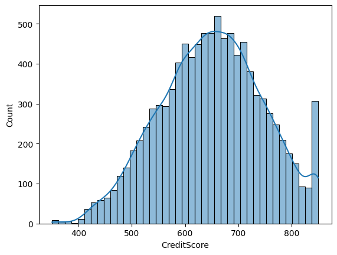

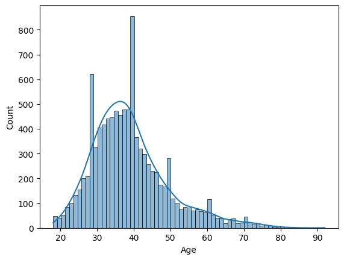

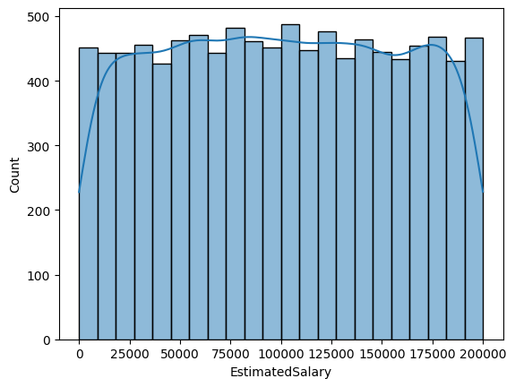

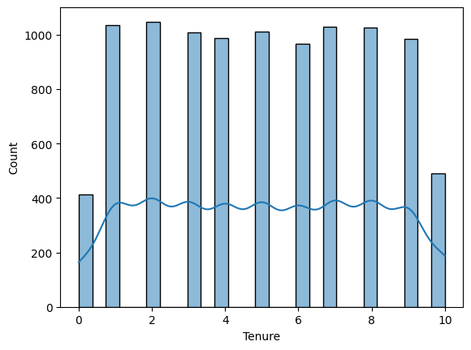

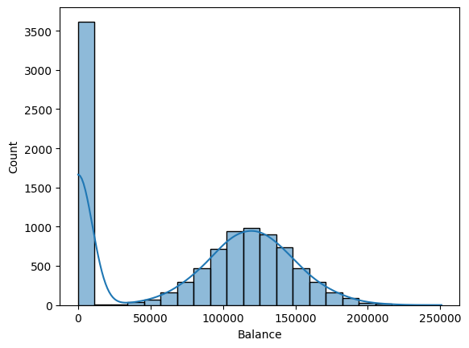

```python
for col in numerical_columns:
  sns.histplot(data=data, x=col, kde=True);
  plt.show()
```

**Observations**

CreditScore seems to be slightly skewed to the left.

Age data is skewed to the right indicating existance of customers who are older. This is expected given the domain.

The Balance data as expected seems to have a wide range from 0 to 250k as some customers may have more balance than the rest.

# Outlier detection using Boxplot

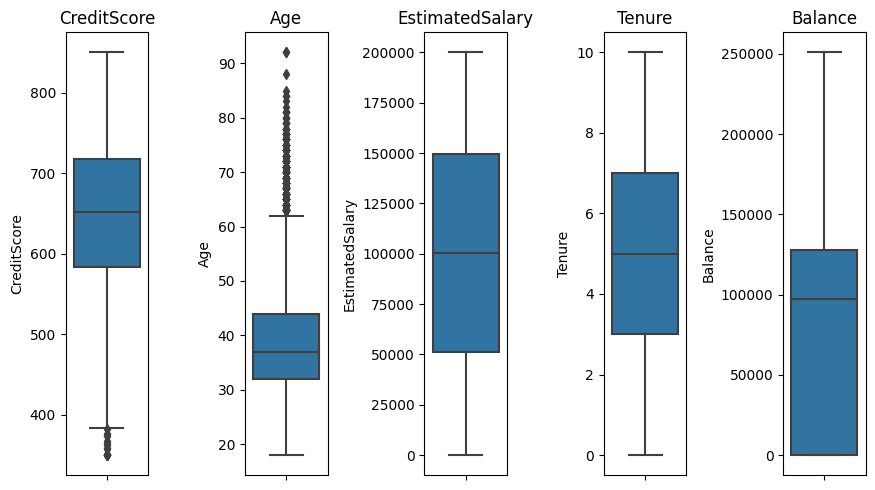

```python
#Let us plot boxplots for all the columns
plt.figure(figsize=(25,5))

for i, variable in enumerate(numerical_columns):
    plt.subplot(1,14,i+1)
    sns.boxplot(y=data[variable], orient='h')
    plt.tight_layout()
    plt.title(variable)

plt.show()
```

**Observations on Outliers derived from Box Plots**

Age and CreditScore columns indicate existance of outliers, however considering the domain, the data seems legitimate and does not warranty any treatment.

# Labeled Bar-plots

```python
# function to create barplots with percentages labled on the bars


def labeled_barplot(data, feature, perc=False, n=None):
    """
    Barplot with percentage at the top

    data: dataframe
    feature: dataframe column
    perc: whether to display percentages instead of count (default is False)
    n: displays the top n category levels (default is None, i.e., display all levels)
    """

    total = len(data[feature])  # length of the column
    count = data[feature].nunique()
    if n is None:
        plt.figure(figsize=(count + 1, 3))
    else:
        plt.figure(figsize=(n + 1, 3))

    plt.xticks(rotation=90, fontsize=15)
    ax = sns.countplot(
        data=data,
        x=feature,
        palette="Paired",
        order=data[feature].value_counts().index[:n].sort_values(),
    )

    for p in ax.patches:
        if perc == True:
            label = "{:.1f}%".format(
                100 * p.get_height() / total
            )  # percentage of each class of the category
        else:
            label = p.get_height()  # count of each level of the category

        x = p.get_x() + p.get_width() / 2  # width of the plot
        y = p.get_height()  # height of the plot

        ax.annotate(
            label,
            (x, y),
            ha="center",
            va="center",
            size=12,
            xytext=(0, 5),
            textcoords="offset points",
        )  # annotate the percentage

    plt.show()  # show the plot
```

```python
candidates_for_barplots = ['Geography', 'Gender',
       'NumOfProducts', 'HasCrCard', 'IsActiveMember', 'Exited']
```

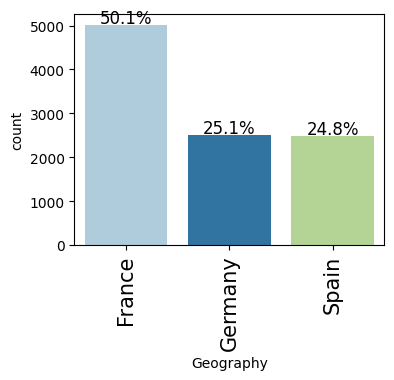

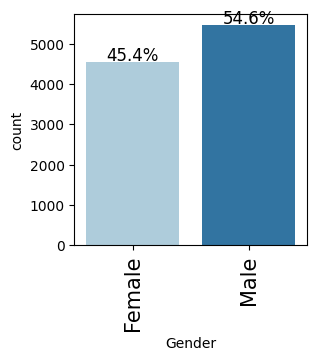

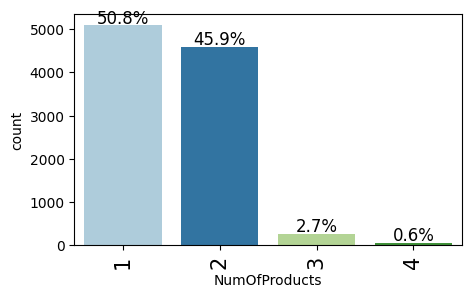

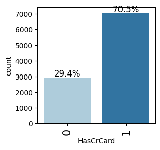

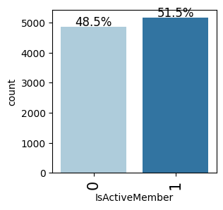

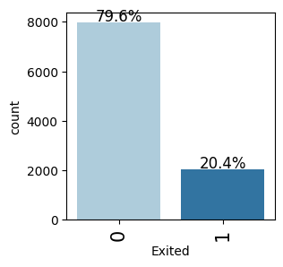

```python
for col in candidates_for_barplots:
 labeled_barplot(data, col, perc=True)
```

**Observations**

50% of the customer base is located in France with the remaining 50% split between Germany and Spain.

55% of the customer base is comprised of Men.

About 51% of the customers seem to have purchased 1 product with the bank and about 46% seems to have purchased 2 products. About 0.6% of the customers have purchased 4 products.

~71% of the customers have a credit card.

~52% of the customers actively use the services at the bank.

80% of the customers stayed with the bank while 20% contribute to the churn. This clearly indicates an imbalance in the data.

# Bivariate Analysis

Goal of Bi-variate analysis is to find inter-dependencies between features.

**Pairplot of all variables with impact on target variable**

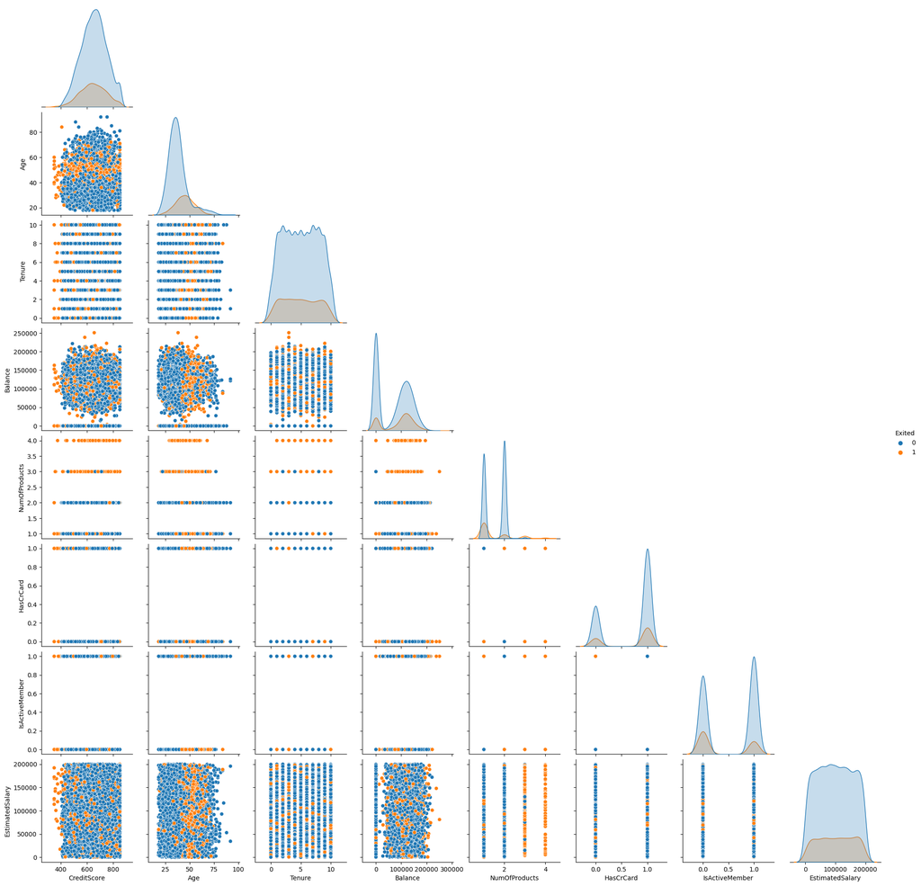

```python
#Draw the pairplot
sns.pairplot(data=data, diag_kind='kde', hue='Exited', corner=True)
plt.show()
```

**Observations**

CreditScore, HasCrCard, IsActiveMember, Tenure and EstimatedSalary do not seem to have an impact on the churning rate.

Customers who purchased 3 or 4 products seem to be among the ones leaving the bank.

Customers between 40 to 60 years of age seem to be the ones leaving the bank.

```python
# function to plot stacked bar chart
def stacked_barplot(data, predictor, target):
    """
    Print the category counts and plot a stacked bar chart

    data: dataframe
    predictor: independent variable
    target: target variable
    """
    count = data[predictor].nunique()
    sorter = data[target].value_counts().index[-1]
    tab1 = pd.crosstab(data[predictor], data[target], margins=True).sort_values(
        by=sorter, ascending=False
    )
    print(tab1)
    print("-" * 120)
    tab = pd.crosstab(data[predictor], data[target], normalize="index").sort_values(
        by=sorter, ascending=False
    )
    tab.plot(kind="bar", stacked=True, figsize=(count + 5, 6))
    plt.legend(
        loc="lower left", frameon=False,
    )
    plt.legend(loc="upper left", bbox_to_anchor=(1, 1))
    plt.show()
```

```
Exited        0     1    All
Geography
All        7963  2037  10000
Germany    1695   814   2509
France     4204   810   5014
Spain      2064   413   2477
------------------------------------------------------------------------------------------------------------------------
```

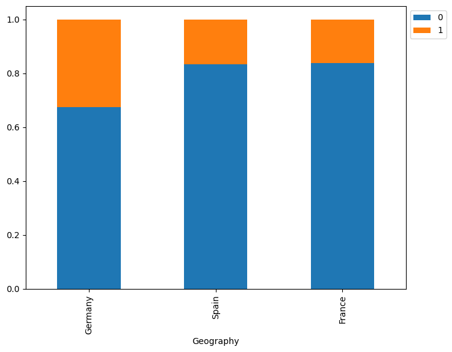

```python
stacked_barplot(data, "Geography", "Exited")
```

**Observation**

Customer from Germany are more likely to leave the bank compared to other countries.

```
Exited     0     1    All
Gender
All     7963  2037  10000
Female  3404  1139   4543
Male    4559   898   5457
------------------------------------------------------------------------------------------------------------------------
```

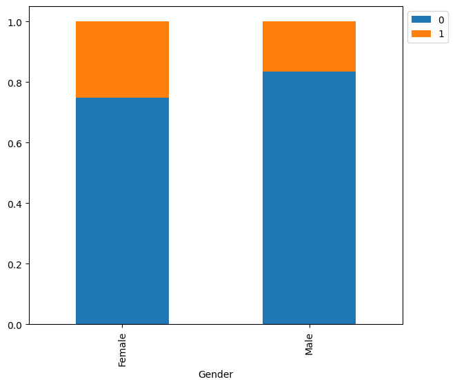

```python
stacked_barplot(data, "Gender", "Exited")
```

**Observation**

Female customers tend to leave the bank more than their male counterparts.

```
Exited             0     1    All
IsActiveMember
All             7963  2037  10000
0               3547  1302   4849
1               4416   735   5151
------------------------------------------------------------------------------------------------------------------------
```

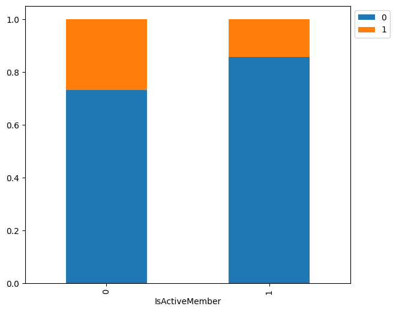

```python
stacked_barplot(data, "IsActiveMember", "Exited")
```

**Observation**

Members who are not actively using the products seem to churn a bit more than the customers who use the products.

```
Exited        0     1    All
HasCrCard
All        7963  2037  10000
1          5631  1424   7055
0          2332   613   2945
------------------------------------------------------------------------------------------------------------------------
```

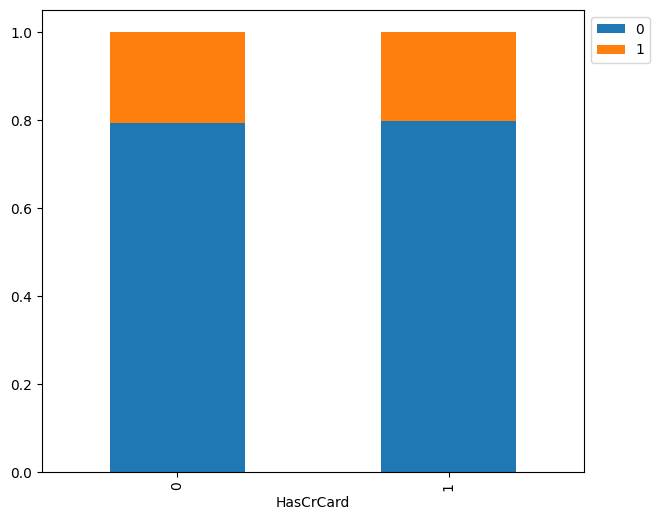

```python
stacked_barplot(data, "HasCrCard", "Exited")
```

**Observation**

Customers having a credit card or not does not seem to have an impact on the churn rate.

```
Exited            0     1    All
NumOfProducts
All            7963  2037  10000
1              3675  1409   5084
2              4242   348   4590
3                46   220    266
4                 0    60     60
------------------------------------------------------------------------------------------------------------------------
```

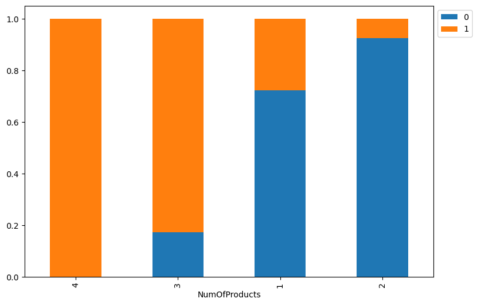

```python
stacked_barplot(data, "NumOfProducts", "Exited")
```

**Observation**

Its obvious that customers who purchased 3 or 4 products from the bank are the ones who are leaving the bank. There is an urgent need to identify the product or products that is causing the churn.

# Multi-variate Analysis

Heatmap to plot the correlations between the columns

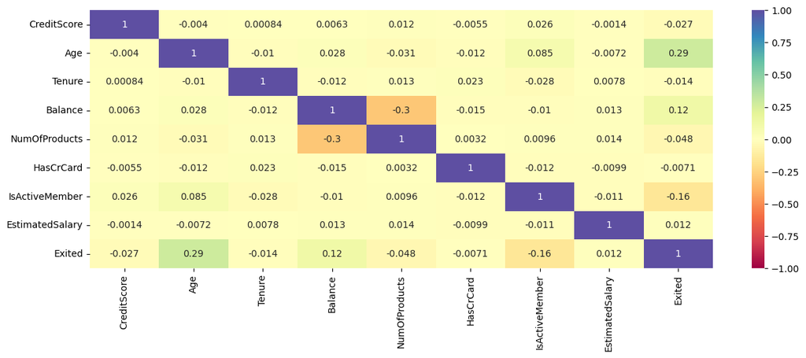

```python
plt.figure(figsize=(15,5))
sns.heatmap(data.corr(), annot=True, vmin=-1, vmax=1, cmap='Spectral');
```

**Observations**

Very weak correlations in general.

NumberOfProducts and Balance have a negative correlation of 0.3

Age seems to have a positive correlation of 0.29 with the target column, Exited.This indicates that older customers are contributing to the churn.

Balance indicates a week positive correlation of 0.12 with the target column, Exited. This goes to indicate that customers with a higher balance seem to be leaving the bank.

# Data Pre-processing

**Define the predictors and the target variable**

```python
X = data.drop(["Exited"], axis=1)
y = data["Exited"]
```

# Splitting data into Training and Testing.

Using 'stratify' to maintain the original distribution of the target variable in the original dataset (80-20).

```python
X_train,X_test, y_train, y_test =train_test_split(X,y, test_size=0.3, random_state=1,stratify=y)
```

# Encoding the Categorical columns

Applying onehot encoding to Gender and Geography columns. We will not drop any of the resulting columns to accomodate any values that exist in the validation/testing sets but not in the training sets.

```python
# Create a OneHotEncoder object
onehot_encoder = OneHotEncoder(sparse=False, handle_unknown="ignore") #setting sparse to False in order to get back an array
cols_to_ohe = ['Gender','Geography']

#Fit the encoder on the training set and transform it on training as well as test datasets
encoded_columns_train = onehot_encoder.fit_transform(X_train[cols_to_ohe])
# Converting the array into a dataframe
data_train_encoded = pd.DataFrame(
   encoded_columns_train,
   index=X_train.index,
   columns=onehot_encoder.get_feature_names_out(cols_to_ohe),
)
# Extract the columns that were not sent through the onehot encoder
data_other_cols_train = X_train.drop(columns=cols_to_ohe)
# Recreate the dataframe
X_train = pd.concat([data_train_encoded, data_other_cols_train], axis=1)

# Transform the test set
encoded_columns_test = onehot_encoder.transform(X_test[cols_to_ohe])
# Convert the array into a dataframe
data_test_encoded = pd.DataFrame(
   encoded_columns_test,
   index=X_test.index,
   columns=onehot_encoder.get_feature_names_out(cols_to_ohe),
)
# Extract the columns that were not sent through the onehot encoder
data_other_cols_test = X_test.drop(columns=cols_to_ohe)
# Recreate the dataframe
X_test = pd.concat([data_test_encoded, data_other_cols_test], axis=1)
```

```python
#Let us take a look at the size of the dataset across the 2 partitions - we should have 3 more columns
#as Gender column has 2 unique values and Geography has 3 unique values. So OneHotEncoder splits the
#Gender column into 2 and the Geography column into 3. So that leaves us with 3 more columns in number.
#Encoding techniques (ordinal or onehot) should not make any changes to the number of rows.
print('Training data set has {} rows and {} columns'.format(X_train.shape[0],X_train.shape[1]))
print('Test data set has {} rows and {} columns'.format(X_test.shape[0],X_test.shape[1]))
```

```
Training data set has 7000 rows and 13 columns
Test data set has 3000 rows and 13 columns
```

Let us inspect the columns in the dataset.

```python
X_train.columns
```

```
Index(['Gender_Female', 'Gender_Male', 'Geography_France', 'Geography_Germany',
       'Geography_Spain', 'CreditScore', 'Age', 'Tenure', 'Balance',
       'NumOfProducts', 'HasCrCard', 'IsActiveMember', 'EstimatedSalary'],
      dtype='object')
```

Gender and Geography columns are replaced by 'Gender_Female', 'Gender_Male', 'Geography_France', 'Geography_Germany' and 'Geography_Spain'

```python
X_train.head(5)
```

|  | Gender_Female | Gender_Male | Geography_France | Geography_Germany | Geography_Spain | CreditScore | Age | Tenure | Balance | NumOfProducts | HasCrCard | IsActiveMember | EstimatedSalary |
| --- | --- | --- | --- | --- | --- | --- | --- | --- | --- | --- | --- | --- | --- |
| 7635 | 1.0 | 0.0 | 1.0 | 0.0 | 0.0 | 516 | 29 | 2 | 104982.57 | 1 | 1 | 0 | 157378.50 |
| 5284 | 0.0 | 1.0 | 0.0 | 1.0 | 0.0 | 745 | 51 | 3 | 99183.90 | 1 | 1 | 1 | 28922.25 |
| 1457 | 0.0 | 1.0 | 1.0 | 0.0 | 0.0 | 850 | 66 | 4 | 0.00 | 2 | 0 | 1 | 64350.80 |
| 4785 | 1.0 | 0.0 | 1.0 | 0.0 | 0.0 | 510 | 22 | 3 | 156834.34 | 1 | 0 | 0 | 44374.44 |
| 9158 | 1.0 | 0.0 | 0.0 | 0.0 | 1.0 | 540 | 31 | 10 | 118158.74 | 1 | 1 | 1 | 158027.57 |

Let us confirm that the dataset no longer has non-numeric columns.

```python
X_train.info()
```

```
<class 'pandas.core.frame.DataFrame'>
Int64Index: 7000 entries, 7635 to 8407
Data columns (total 13 columns):
 #   Column             Non-Null Count  Dtype
---  ------             --------------  -----
 0   Gender_Female      7000 non-null   float64
 1   Gender_Male        7000 non-null   float64
 2   Geography_France   7000 non-null   float64
 3   Geography_Germany  7000 non-null   float64
 4   Geography_Spain    7000 non-null   float64
 5   CreditScore        7000 non-null   int64
 6   Age                7000 non-null   int64
 7   Tenure             7000 non-null   int64
 8   Balance            7000 non-null   float64
 9   NumOfProducts      7000 non-null   int64
 10  HasCrCard          7000 non-null   int64
 11  IsActiveMember     7000 non-null   int64
 12  EstimatedSalary    7000 non-null   float64
dtypes: float64(7), int64(6)
memory usage: 765.6 KB
```

**What is feature scaling?**

Feature scaling is a class of statistical techniques that, as the name implies, scales the features of our data so that they all have a similar range.

If you have multiple independent variables like age, salary, and height, with their range as (18–100 Years), (25,000–75,000 Euros), and (1–2 Meters) respectively, feature scaling would help them all to be in the same range.

```python
#Use StandardScaler() to transform the train and test sets
scaler=StandardScaler()
X_train=scaler.fit_transform(X_train)
X_test=scaler.transform(X_test)
```

# Model Building

**Model Evaluation**

Model evaluation criterion

**Model can make wrong predictions as:**

Predicting that a customer will leave and the customer stays with bank.

Predicting that customer will stay, but the customer actually leaves the bank.

**Which case is more important?** Predicting that customer will stay, but customer actually leaves. This will cause the bank to loose customers and business. Also the marketing and promotional effort will not be made towards retaining these customers.

**How to reduce this loss i.e need to reduce False Negative?** The company would want the recall to be maximized. Greater the recall score, higher are the chances of minimizing the False Negatives.

**BottomLine** - We want the False Negatives to be at a minimum.

# Building a very basic Artificial Neural Network - Model 1

Model1 will be configured with the following:

- 3 layers - relu activation function for the hidden layer and sigmoid activation for the output layer.
- Stochastic Gradient Descent with the default learning rate as our optimizer
- Threshold will be hard-coded to 0.5

The neural network will be configured to take in a vector of length 13 as input. For each transaction, the final layer will output a probability.

```python
#Function to fix the seed for random number generators to ensure we get back the same output everytime
def set_seed_and_clear_session():
  backend.clear_session()

  np.random.seed(42)
  import random
  random.seed(42)
  tf.random.set_seed(42)
```

```python
#Function to generate the confusion matrix
def make_confusion_matrix(cf,
                          group_names=None,
                          categories='auto',
                          count=True,
                          percent=True,
                          cbar=True,
                          xyticks=True,
                          xyplotlabels=True,
                          sum_stats=True,
                          figsize=None,
                          cmap='Blues',
                          title=None):
    '''
    This function will make a pretty plot of an sklearn Confusion Matrix cm using a Seaborn heatmap visualization.
    Arguments
    '''


    # CODE TO GENERATE TEXT INSIDE EACH SQUARE
    blanks = ['' for i in range(cf.size)]

    if group_names and len(group_names)==cf.size:
        group_labels = ["{}\n".format(value) for value in group_names]
    else:
        group_labels = blanks

    if count:
        group_counts = ["{0:0.0f}\n".format(value) for value in cf.flatten()]
    else:
        group_counts = blanks

    if percent:
        group_percentages = ["{0:.2%}".format(value) for value in cf.flatten()/np.sum(cf)]
    else:
        group_percentages = blanks

    box_labels = [f"{v1}{v2}{v3}".strip() for v1, v2, v3 in zip(group_labels,group_counts,group_percentages)]
    box_labels = np.asarray(box_labels).reshape(cf.shape[0],cf.shape[1])


    # CODE TO GENERATE SUMMARY STATISTICS & TEXT FOR SUMMARY STATS
    if sum_stats:
        #Accuracy is sum of diagonal divided by total observations
        accuracy  = np.trace(cf) / float(np.sum(cf))



    # SET FIGURE PARAMETERS ACCORDING TO OTHER ARGUMENTS
    if figsize==None:
        #Get default figure size if not set
        figsize = plt.rcParams.get('figure.figsize')

    if xyticks==False:
        #Do not show categories if xyticks is False
        categories=False


    # MAKE THE HEATMAP VISUALIZATION
    plt.figure(figsize=figsize)
    sns.heatmap(cf,annot=box_labels,fmt="",cmap=cmap,cbar=cbar,xticklabels=categories,yticklabels=categories)


    if title:
        plt.title(title)
```

```python
#Function to draw the AUC-ROC curve and update the predictions based on the best threshold
def draw_roc_curve(y_predictions):

  # calculate roc curves
  fpr, tpr, thresholds1 = roc_curve(y_test, y_predictions)
  # calculate the g-mean for each threshold
  gmeans1 = np.sqrt(tpr * (1-fpr))
  # locate the index of the largest g-mean
  ix = np.argmax(gmeans1)
  print('Best Threshold=%f, G-Mean=%.3f' % (thresholds1[ix], gmeans1[ix]))
  # plot the roc curve for the model
  pyplot.plot([0,1], [0,1], linestyle='--', label='No Skill')
  pyplot.plot(fpr, tpr, marker='.')
  pyplot.scatter(fpr[ix], tpr[ix], marker='o', color='black', label='Best')
  # axis labels
  pyplot.xlabel('False Positive Rate')
  pyplot.ylabel('True Positive Rate')
  pyplot.legend()
  # show the plot
  pyplot.show()
  for i in range(len(y_test)):
    if y_predictions[i]>thresholds1[ix]:
        y_predictions[i]=1
    else:
        y_predictions[i]=0
  return y_predictions
```

**Initializing model_1**

```python
# Initializing the ANN
# We will be adding the layers sequentially
model_1 = Sequential()

#This adds the input layer with 64 neurons with the relu activation function, the input shape tuple denotes the number of predictors
model_1.add(Dense(64, activation='relu', input_shape=(13,)))

# First hidden layer with 32 neurons and relu activation function
model_1.add(Dense(32, activation='relu'))


# Output layer - We use the sigmoid because we want probability outcomes - binary classification
model_1.add(Dense(1,activation='sigmoid'))
```

**Compiling model_1**

```python
# Compiling the model using the Stochastic Gradient Descent optimizer set to the default learning rate
model_1.compile(optimizer='SGD', loss='binary_crossentropy', metrics=['accuracy'])
```

**Model (model_1) Summary**

```python
model_1.summary()
```

```
Model: "sequential_2"
_________________________________________________________________
 Layer (type)                Output Shape              Param #
=================================================================
 dense_14 (Dense)            (None, 64)                896

 dense_15 (Dense)            (None, 32)                2080

 dense_16 (Dense)            (None, 1)                 33

=================================================================
Total params: 3,009
Trainable params: 3,009
Non-trainable params: 0
_________________________________________________________________
```

**Training model_1**

```python
history_1 = model_1.fit(X_train,
                    y_train,
                    validation_split=0.2,
                    epochs=50,
                    verbose=2)
```

```
175/175 - 1s - loss: 0.5477 - accuracy: 0.7764 - val_loss: 0.5103 - val_accuracy: 0.7807 - 1s/epoch - 6ms/step
175/175 - 0s - loss: 0.4746 - accuracy: 0.8002 - val_loss: 0.4877 - val_accuracy: 0.7807 - 310ms/epoch - 2ms/step
175/175 - 0s - loss: 0.4566 - accuracy: 0.8002 - val_loss: 0.4741 - val_accuracy: 0.7807 - 318ms/epoch - 2ms/step
175/175 - 0s - loss: 0.4452 - accuracy: 0.8005 - val_loss: 0.4643 - val_accuracy: 0.7843 - 331ms/epoch - 2ms/step
175/175 - 0s - loss: 0.4366 - accuracy: 0.8014 - val_loss: 0.4567 - val_accuracy: 0.7886 - 307ms/epoch - 2ms/step
175/175 - 0s - loss: 0.4295 - accuracy: 0.8052 - val_loss: 0.4501 - val_accuracy: 0.7943 - 316ms/epoch - 2ms/step
175/175 - 0s - loss: 0.4236 - accuracy: 0.8095 - val_loss: 0.4441 - val_accuracy: 0.8021 - 333ms/epoch - 2ms/step
175/175 - 0s - loss: 0.4183 - accuracy: 0.8132 - val_loss: 0.4390 - val_accuracy: 0.8057 - 340ms/epoch - 2ms/step
175/175 - 0s - loss: 0.4135 - accuracy: 0.8166 - val_loss: 0.4344 - val_accuracy: 0.8079 - 404ms/epoch - 2ms/step
175/175 - 0s - loss: 0.4088 - accuracy: 0.8193 - val_loss: 0.4303 - val_accuracy: 0.8114 - 416ms/epoch - 2ms/step
175/175 - 0s - loss: 0.4044 - accuracy: 0.8225 - val_loss: 0.4255 - val_accuracy: 0.8164 - 312ms/epoch - 2ms/step
175/175 - 0s - loss: 0.4000 - accuracy: 0.8250 - val_loss: 0.4205 - val_accuracy: 0.8193 - 323ms/epoch - 2ms/step
175/175 - 0s - loss: 0.3956 - accuracy: 0.8284 - val_loss: 0.4166 - val_accuracy: 0.8221 - 305ms/epoch - 2ms/step
175/175 - 0s - loss: 0.3911 - accuracy: 0.8320 - val_loss: 0.4121 - val_accuracy: 0.8286 - 321ms/epoch - 2ms/step
175/175 - 0s - loss: 0.3866 - accuracy: 0.8357 - val_loss: 0.4068 - val_accuracy: 0.8343 - 406ms/epoch - 2ms/step
175/175 - 0s - loss: 0.3822 - accuracy: 0.8382 - val_loss: 0.4022 - val_accuracy: 0.8343 - 431ms/epoch - 2ms/step
175/175 - 0s - loss: 0.3777 - accuracy: 0.8420 - val_loss: 0.3984 - val_accuracy: 0.8393 - 498ms/epoch - 3ms/step
175/175 - 0s - loss: 0.3732 - accuracy: 0.8436 - val_loss: 0.3935 - val_accuracy: 0.8436 - 430ms/epoch - 2ms/step
175/175 - 0s - loss: 0.3689 - accuracy: 0.8479 - val_loss: 0.3897 - val_accuracy: 0.8443 - 430ms/epoch - 2ms/step
175/175 - 0s - loss: 0.3646 - accuracy: 0.8496 - val_loss: 0.3850 - val_accuracy: 0.8479 - 448ms/epoch - 3ms/step
175/175 - 1s - loss: 0.3605 - accuracy: 0.8532 - val_loss: 0.3815 - val_accuracy: 0.8493 - 500ms/epoch - 3ms/step
175/175 - 0s - loss: 0.3566 - accuracy: 0.8545 - val_loss: 0.3792 - val_accuracy: 0.8500 - 444ms/epoch - 3ms/step
175/175 - 0s - loss: 0.3532 - accuracy: 0.8559 - val_loss: 0.3745 - val_accuracy: 0.8543 - 403ms/epoch - 2ms/step
175/175 - 0s - loss: 0.3501 - accuracy: 0.8577 - val_loss: 0.3726 - val_accuracy: 0.8529 - 494ms/epoch - 3ms/step
175/175 - 0s - loss: 0.3472 - accuracy: 0.8596 - val_loss: 0.3695 - val_accuracy: 0.8550 - 417ms/epoch - 2ms/step
175/175 - 0s - loss: 0.3448 - accuracy: 0.8609 - val_loss: 0.3680 - val_accuracy: 0.8564 - 311ms/epoch - 2ms/step
175/175 - 0s - loss: 0.3425 - accuracy: 0.8614 - val_loss: 0.3675 - val_accuracy: 0.8586 - 305ms/epoch - 2ms/step
175/175 - 0s - loss: 0.3405 - accuracy: 0.8630 - val_loss: 0.3643 - val_accuracy: 0.8543 - 316ms/epoch - 2ms/step
175/175 - 0s - loss: 0.3387 - accuracy: 0.8623 - val_loss: 0.3631 - val_accuracy: 0.8536 - 318ms/epoch - 2ms/step
175/175 - 0s - loss: 0.3369 - accuracy: 0.8639 - val_loss: 0.3615 - val_accuracy: 0.8507 - 325ms/epoch - 2ms/step
175/175 - 0s - loss: 0.3355 - accuracy: 0.8637 - val_loss: 0.3626 - val_accuracy: 0.8564 - 321ms/epoch - 2ms/step
175/175 - 0s - loss: 0.3342 - accuracy: 0.8648 - val_loss: 0.3612 - val_accuracy: 0.8529 - 305ms/epoch - 2ms/step
175/175 - 0s - loss: 0.3329 - accuracy: 0.8655 - val_loss: 0.3596 - val_accuracy: 0.8507 - 316ms/epoch - 2ms/step
175/175 - 0s - loss: 0.3318 - accuracy: 0.8650 - val_loss: 0.3595 - val_accuracy: 0.8514 - 319ms/epoch - 2ms/step
175/175 - 0s - loss: 0.3308 - accuracy: 0.8661 - val_loss: 0.3592 - val_accuracy: 0.8500 - 312ms/epoch - 2ms/step
175/175 - 0s - loss: 0.3295 - accuracy: 0.8661 - val_loss: 0.3588 - val_accuracy: 0.8521 - 311ms/epoch - 2ms/step
175/175 - 0s - loss: 0.3287 - accuracy: 0.8671 - val_loss: 0.3598 - val_accuracy: 0.8536 - 317ms/epoch - 2ms/step
175/175 - 0s - loss: 0.3281 - accuracy: 0.8670 - val_loss: 0.3586 - val_accuracy: 0.8479 - 311ms/epoch - 2ms/step
175/175 - 0s - loss: 0.3272 - accuracy: 0.8668 - val_loss: 0.3582 - val_accuracy: 0.8500 - 315ms/epoch - 2ms/step
175/175 - 0s - loss: 0.3266 - accuracy: 0.8680 - val_loss: 0.3580 - val_accuracy: 0.8507 - 314ms/epoch - 2ms/step
175/175 - 0s - loss: 0.3259 - accuracy: 0.8668 - val_loss: 0.3580 - val_accuracy: 0.8507 - 300ms/epoch - 2ms/step
175/175 - 0s - loss: 0.3252 - accuracy: 0.8680 - val_loss: 0.3578 - val_accuracy: 0.8507 - 321ms/epoch - 2ms/step
175/175 - 0s - loss: 0.3246 - accuracy: 0.8679 - val_loss: 0.3572 - val_accuracy: 0.8500 - 310ms/epoch - 2ms/step
175/175 - 0s - loss: 0.3239 - accuracy: 0.8675 - val_loss: 0.3579 - val_accuracy: 0.8507 - 319ms/epoch - 2ms/step
175/175 - 0s - loss: 0.3235 - accuracy: 0.8693 - val_loss: 0.3578 - val_accuracy: 0.8529 - 313ms/epoch - 2ms/step
175/175 - 0s - loss: 0.3229 - accuracy: 0.8686 - val_loss: 0.3571 - val_accuracy: 0.8514 - 361ms/epoch - 2ms/step
175/175 - 1s - loss: 0.3224 - accuracy: 0.8682 - val_loss: 0.3578 - val_accuracy: 0.8529 - 543ms/epoch - 3ms/step
175/175 - 0s - loss: 0.3219 - accuracy: 0.8686 - val_loss: 0.3580 - val_accuracy: 0.8536 - 408ms/epoch - 2ms/step
175/175 - 0s - loss: 0.3212 - accuracy: 0.8698 - val_loss: 0.3577 - val_accuracy: 0.8529 - 421ms/epoch - 2ms/step
175/175 - 0s - loss: 0.3208 - accuracy: 0.8695 - val_loss: 0.3585 - val_accuracy: 0.8521 - 332ms/epoch - 2ms/step
```

**Plotting Train Accuracy vs Validation Accuracy**

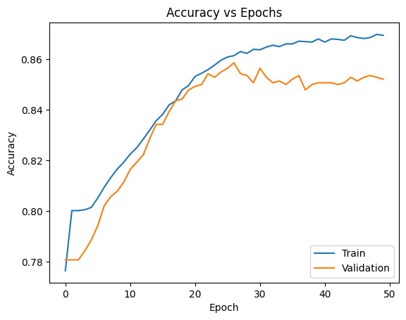

```python
plt.plot(history_1.history['accuracy'])
plt.plot(history_1.history['val_accuracy'])
plt.title('Accuracy vs Epochs')
plt.ylabel('Accuracy')
plt.xlabel('Epoch')
plt.legend(['Train', 'Validation'], loc='lower right')
plt.show()
```

**Observation** - Based on the accuracy graphs, the accuracy did not improve after 20 epochs in the validation dataset. The model is slightly overfitting.

**Plotting Train Loss vs Validation Loss**

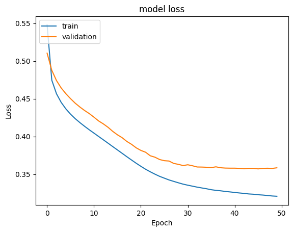

```python
plt.plot(history_1.history['loss'])
plt.plot(history_1.history['val_loss'])
plt.title('model loss')
plt.ylabel('Loss')
plt.xlabel('Epoch')
plt.legend(['train', 'validation'], loc='upper left')
plt.show()
```

The loss is decreasing and seems to stabilize at around 40 epochs for the validation dataset.

**Evaluating the Model against the test/unseen data**

```python
score1 = model_1.evaluate(X_test, y_test)
```

[output not shown]

The basic model, model_1 gives an accuracy of ~86 on the test data.

**Let us set the threshold to 0.5 - output values greater than 0.5 will be evaluated as 1 and values less than or equal to 0.5 will be evaluated as 0.**

```python
y_pred1 = model_1.predict(X_test)
for i in range(len(y_test)):
    if y_pred1[i]>0.5:
        y_pred1[i]=1
    else:
        y_pred1[i]=0
```

**Generating the Confusion Matrix**

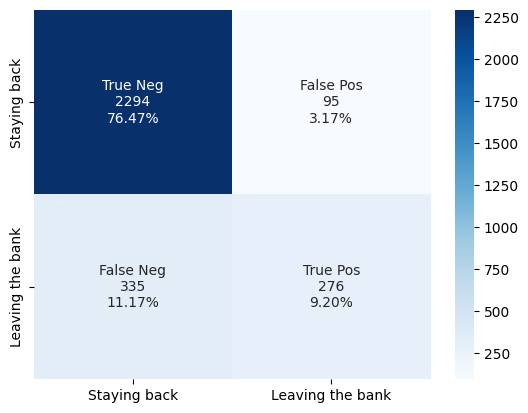

```python
#Calculating the confusion matrix
from sklearn.metrics import confusion_matrix
cm1=confusion_matrix(y_test, y_pred1)
#labels = ['True Positive','False Negative','False Positive','True Negative']
labels = ['True Neg','False Pos','False Neg','True Pos']
categories = [ 'Staying back','Leaving the bank']
make_confusion_matrix(cm1,
                      group_names=labels,
                      categories=categories,
                      cmap='Blues')
```

The model has incorrectly forecasted 95 customers as ones who would leave the bank where in reality they stayed with the bank - this is our case of False Positives.

False Negatives - The model predicted some 335 customers would stay with the bank but in reality these customers left the bank. These are the cases we need to reduce as recall is the metric we are focused on.

```python
#Accuracy as per the classification report
cr=classification_report(y_test,y_pred1)
print(cr)
```

```
              precision    recall  f1-score   support

           0       0.87      0.96      0.91      2389
           1       0.74      0.45      0.56       611

    accuracy                           0.86      3000
   macro avg       0.81      0.71      0.74      3000
weighted avg       0.85      0.86      0.84      3000
```

```python
recall1 =0.45
```

**As you can see, the above model has a low recall value of 0.45. The imbalanced dataset could be contributing to the poor recall value.**

**In Model 1, we hardcoded the threshold to 0.5. Given the imbalanced dataset, we will benefit from using the ROC-AUC to determine the optimal threshold.**

**For the next model, let us change the optimizer, tune the decision threshold, utilize the Dropout technique to increase the model performance**

# Model 2

Model2 will be configured with the following:

- 3 layers - relu activation function for the hidden layer and sigmoid activation for the output layer.
- Adam Optimizer with a learning rate of 0.001
- Threshold will be determined using the ROC-AUC curve
- Dropout technique will be utilized - Dropout(0.5)
- batch_size=128

The neural network will be configured to take in a vector of length 13 as input. For each transaction, the final layer will output a probability.

```python
set_seed_and_clear_session()
```

```python
# Initializing the ANN
# We will be adding the layers sequentially
model_2 = Sequential()

#This adds the input layer with 64 neurons with the relu activation function, the input shape tuple denotes the number of predictors
model_2.add(Dense(64, activation='relu',kernel_initializer='he_uniform',input_shape=(13,)))

# First hidden layer with 32 neurons and relu activation function
model_2.add(Dense(32, activation='relu',kernel_initializer='he_uniform'))
model_2.add(Dropout(0.5))

# Output layer - We use the sigmoid because we want probability outcomes - binary classification
model_2.add(Dense(1,activation='sigmoid'))
```

```python
# Compiling the model using the Adam optimizer
adam = optimizers.Adam(learning_rate=1e-3)
model_2.compile(loss=losses.binary_crossentropy, optimizer=adam, metrics=['accuracy'])
```

```python
model_2.summary()
```

```
Model: "sequential"
_________________________________________________________________
 Layer (type)                Output Shape              Param #
=================================================================
 dense (Dense)               (None, 64)                896

 dense_1 (Dense)             (None, 32)                2080

 dropout (Dropout)           (None, 32)                0

 dense_2 (Dense)             (None, 1)                 33

=================================================================
Total params: 3,009
Trainable params: 3,009
Non-trainable params: 0
_________________________________________________________________
```

```python
history_2 = model_2.fit(X_train,
                    y_train,
                    validation_split=0.2,
                    epochs=50,
                    batch_size=128,
                    verbose=2)
```

```
44/44 - 3s - loss: 0.6221 - accuracy: 0.7305 - val_loss: 0.4927 - val_accuracy: 0.7843 - 3s/epoch - 58ms/step
44/44 - 0s - loss: 0.4956 - accuracy: 0.7827 - val_loss: 0.4676 - val_accuracy: 0.7943 - 256ms/epoch - 6ms/step
44/44 - 0s - loss: 0.4718 - accuracy: 0.8000 - val_loss: 0.4592 - val_accuracy: 0.7986 - 300ms/epoch - 7ms/step
44/44 - 0s - loss: 0.4555 - accuracy: 0.8054 - val_loss: 0.4501 - val_accuracy: 0.8057 - 249ms/epoch - 6ms/step
44/44 - 0s - loss: 0.4445 - accuracy: 0.8107 - val_loss: 0.4449 - val_accuracy: 0.8071 - 253ms/epoch - 6ms/step
44/44 - 0s - loss: 0.4321 - accuracy: 0.8196 - val_loss: 0.4401 - val_accuracy: 0.8064 - 215ms/epoch - 5ms/step
44/44 - 0s - loss: 0.4253 - accuracy: 0.8202 - val_loss: 0.4317 - val_accuracy: 0.8207 - 248ms/epoch - 6ms/step
44/44 - 0s - loss: 0.4179 - accuracy: 0.8245 - val_loss: 0.4264 - val_accuracy: 0.8207 - 208ms/epoch - 5ms/step
44/44 - 0s - loss: 0.4131 - accuracy: 0.8263 - val_loss: 0.4194 - val_accuracy: 0.8279 - 284ms/epoch - 6ms/step
44/44 - 0s - loss: 0.4027 - accuracy: 0.8327 - val_loss: 0.4169 - val_accuracy: 0.8279 - 206ms/epoch - 5ms/step
44/44 - 0s - loss: 0.4030 - accuracy: 0.8363 - val_loss: 0.4066 - val_accuracy: 0.8429 - 207ms/epoch - 5ms/step
44/44 - 0s - loss: 0.3946 - accuracy: 0.8354 - val_loss: 0.4006 - val_accuracy: 0.8457 - 175ms/epoch - 4ms/step
44/44 - 0s - loss: 0.3922 - accuracy: 0.8382 - val_loss: 0.3995 - val_accuracy: 0.8400 - 195ms/epoch - 4ms/step
44/44 - 0s - loss: 0.3812 - accuracy: 0.8441 - val_loss: 0.3921 - val_accuracy: 0.8493 - 153ms/epoch - 3ms/step
44/44 - 0s - loss: 0.3872 - accuracy: 0.8393 - val_loss: 0.3891 - val_accuracy: 0.8486 - 122ms/epoch - 3ms/step
44/44 - 0s - loss: 0.3827 - accuracy: 0.8455 - val_loss: 0.3859 - val_accuracy: 0.8479 - 166ms/epoch - 4ms/step
44/44 - 0s - loss: 0.3733 - accuracy: 0.8450 - val_loss: 0.3833 - val_accuracy: 0.8493 - 137ms/epoch - 3ms/step
44/44 - 0s - loss: 0.3724 - accuracy: 0.8475 - val_loss: 0.3793 - val_accuracy: 0.8500 - 118ms/epoch - 3ms/step
44/44 - 0s - loss: 0.3691 - accuracy: 0.8461 - val_loss: 0.3785 - val_accuracy: 0.8536 - 125ms/epoch - 3ms/step
44/44 - 0s - loss: 0.3658 - accuracy: 0.8477 - val_loss: 0.3775 - val_accuracy: 0.8521 - 252ms/epoch - 6ms/step
44/44 - 0s - loss: 0.3576 - accuracy: 0.8502 - val_loss: 0.3732 - val_accuracy: 0.8536 - 184ms/epoch - 4ms/step
44/44 - 0s - loss: 0.3624 - accuracy: 0.8507 - val_loss: 0.3741 - val_accuracy: 0.8536 - 186ms/epoch - 4ms/step
44/44 - 0s - loss: 0.3633 - accuracy: 0.8504 - val_loss: 0.3720 - val_accuracy: 0.8521 - 236ms/epoch - 5ms/step
44/44 - 0s - loss: 0.3555 - accuracy: 0.8541 - val_loss: 0.3718 - val_accuracy: 0.8557 - 207ms/epoch - 5ms/step
44/44 - 0s - loss: 0.3584 - accuracy: 0.8493 - val_loss: 0.3692 - val_accuracy: 0.8543 - 194ms/epoch - 4ms/step
44/44 - 0s - loss: 0.3620 - accuracy: 0.8495 - val_loss: 0.3698 - val_accuracy: 0.8500 - 121ms/epoch - 3ms/step
44/44 - 0s - loss: 0.3538 - accuracy: 0.8532 - val_loss: 0.3696 - val_accuracy: 0.8586 - 184ms/epoch - 4ms/step
44/44 - 0s - loss: 0.3463 - accuracy: 0.8541 - val_loss: 0.3693 - val_accuracy: 0.8557 - 118ms/epoch - 3ms/step
44/44 - 0s - loss: 0.3512 - accuracy: 0.8534 - val_loss: 0.3711 - val_accuracy: 0.8579 - 126ms/epoch - 3ms/step
44/44 - 0s - loss: 0.3498 - accuracy: 0.8548 - val_loss: 0.3678 - val_accuracy: 0.8521 - 219ms/epoch - 5ms/step
44/44 - 0s - loss: 0.3465 - accuracy: 0.8562 - val_loss: 0.3681 - val_accuracy: 0.8579 - 146ms/epoch - 3ms/step
44/44 - 0s - loss: 0.3475 - accuracy: 0.8552 - val_loss: 0.3682 - val_accuracy: 0.8579 - 193ms/epoch - 4ms/step
44/44 - 0s - loss: 0.3443 - accuracy: 0.8573 - val_loss: 0.3691 - val_accuracy: 0.8579 - 143ms/epoch - 3ms/step
44/44 - 0s - loss: 0.3458 - accuracy: 0.8557 - val_loss: 0.3675 - val_accuracy: 0.8543 - 165ms/epoch - 4ms/step
44/44 - 0s - loss: 0.3446 - accuracy: 0.8557 - val_loss: 0.3701 - val_accuracy: 0.8564 - 221ms/epoch - 5ms/step
44/44 - 0s - loss: 0.3436 - accuracy: 0.8571 - val_loss: 0.3699 - val_accuracy: 0.8571 - 182ms/epoch - 4ms/step
44/44 - 0s - loss: 0.3383 - accuracy: 0.8629 - val_loss: 0.3687 - val_accuracy: 0.8557 - 226ms/epoch - 5ms/step
44/44 - 0s - loss: 0.3386 - accuracy: 0.8589 - val_loss: 0.3671 - val_accuracy: 0.8550 - 120ms/epoch - 3ms/step
44/44 - 0s - loss: 0.3400 - accuracy: 0.8570 - val_loss: 0.3681 - val_accuracy: 0.8571 - 131ms/epoch - 3ms/step
44/44 - 0s - loss: 0.3329 - accuracy: 0.8634 - val_loss: 0.3694 - val_accuracy: 0.8529 - 119ms/epoch - 3ms/step
44/44 - 0s - loss: 0.3444 - accuracy: 0.8591 - val_loss: 0.3682 - val_accuracy: 0.8543 - 195ms/epoch - 4ms/step
44/44 - 0s - loss: 0.3362 - accuracy: 0.8591 - val_loss: 0.3689 - val_accuracy: 0.8521 - 125ms/epoch - 3ms/step
44/44 - 0s - loss: 0.3364 - accuracy: 0.8616 - val_loss: 0.3683 - val_accuracy: 0.8529 - 170ms/epoch - 4ms/step
44/44 - 0s - loss: 0.3324 - accuracy: 0.8616 - val_loss: 0.3679 - val_accuracy: 0.8479 - 179ms/epoch - 4ms/step
44/44 - 0s - loss: 0.3379 - accuracy: 0.8573 - val_loss: 0.3695 - val_accuracy: 0.8500 - 120ms/epoch - 3ms/step
44/44 - 0s - loss: 0.3345 - accuracy: 0.8607 - val_loss: 0.3701 - val_accuracy: 0.8564 - 146ms/epoch - 3ms/step
44/44 - 0s - loss: 0.3312 - accuracy: 0.8620 - val_loss: 0.3704 - val_accuracy: 0.8521 - 223ms/epoch - 5ms/step
44/44 - 0s - loss: 0.3318 - accuracy: 0.8625 - val_loss: 0.3711 - val_accuracy: 0.8521 - 253ms/epoch - 6ms/step
44/44 - 0s - loss: 0.3310 - accuracy: 0.8627 - val_loss: 0.3689 - val_accuracy: 0.8514 - 245ms/epoch - 6ms/step
44/44 - 0s - loss: 0.3342 - accuracy: 0.8589 - val_loss: 0.3706 - val_accuracy: 0.8500 - 347ms/epoch - 8ms/step
```

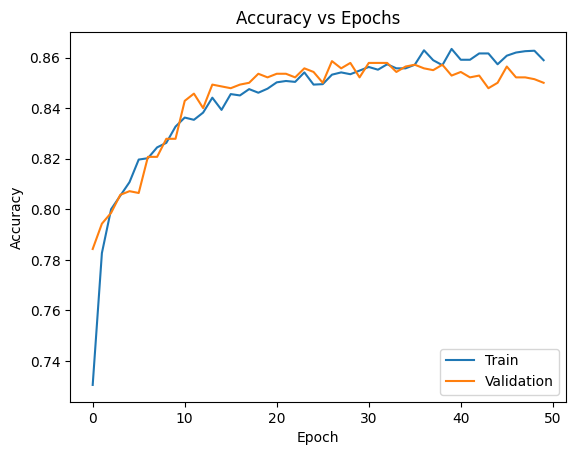

```python
#Plotting Train Accuracy vs Validation Accuracy
plt.plot(history_2.history['accuracy'])
plt.plot(history_2.history['val_accuracy'])
plt.title('Accuracy vs Epochs')
plt.ylabel('Accuracy')
plt.xlabel('Epoch')
plt.legend(['Train', 'Validation'], loc='lower right')
plt.show()
```

Though there is a bit of noise, model seems to do well with both the training as well as the validation datasets.

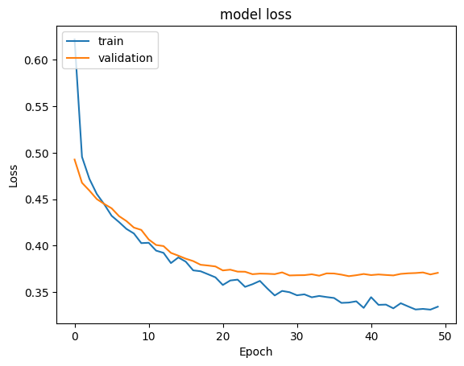

```python
#Plotting Train Loss vs Validation Loss
plt.plot(history_2.history['loss'])
plt.plot(history_2.history['val_loss'])
plt.title('model loss')
plt.ylabel('Loss')
plt.xlabel('Epoch')
plt.legend(['train', 'validation'], loc='upper left')
plt.show()
```

The loss in the validation dataset is slightly higer. Overall the model is generalizing well and does not seem to overfit.

```python
score2 = model_2.evaluate(X_test, y_test)
```

```
Best Threshold=0.160839, G-Mean=0.765
```

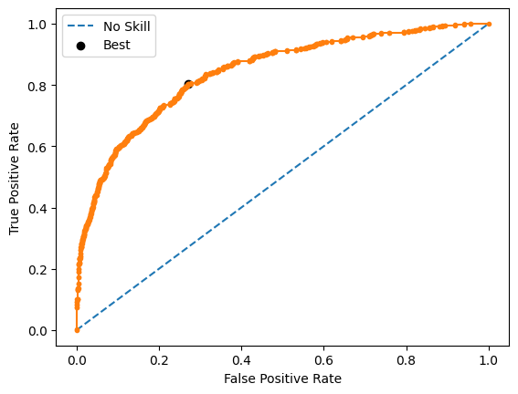

```python
# predict probabilities
ypred_2 = model_2.predict(X_test)
# keep probabilities for the positive outcome only
ypred_2 = ypred_2[:, 0]
ypred_2 = draw_roc_curve(ypred_2)
```

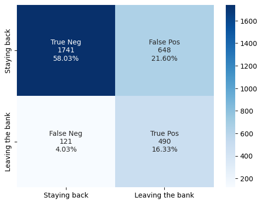

```python
#Calculating the confusion matrix
from sklearn.metrics import confusion_matrix
cm1=confusion_matrix(y_test, ypred_2)

labels = ['True Neg','False Pos','False Neg','True Pos']
categories = [ 'Staying back','Leaving the bank']
make_confusion_matrix(cm1,
                      group_names=labels,
                      categories=categories,
                      cmap='Blues')
```

The False Negatives count has come down from 335 in Model1 to 121 in Model2.

```python
#Accuracy as per the classification report
cr=classification_report(y_test,ypred_2)
print(cr)
```

```
              precision    recall  f1-score   support

           0       0.94      0.73      0.82      2389
           1       0.43      0.80      0.56       611

    accuracy                           0.74      3000
   macro avg       0.68      0.77      0.69      3000
weighted avg       0.83      0.74      0.77      3000
```

```python
recall2 =0.80
```

**The recall value has gone up from 0.45 (in model1) to 0.80. Clearly Model2 is performing better compared to Model1 and it generalizes well across both the validation and training sets.**

**Let us increase the number of layers and introduce BatchNormalization to see we can improve on the recall score any further.**

# Model 3

Model3 will be configured with the following:

- 5 layers - relu activation function for the hidden layer and sigmoid activation for the output layer. (Model 1 & 2 had only 3 layers)
- Adam Optimizer with a learning rate of 0.01 (Model 2 had a 0.001 learning rate)
- Threshold will be determined using the ROC-AUC curve
- Both Dropout and BatchNormalization techniques will be utilized. (Model 2 used the Dropout technique alone)
- batch_size=128

The neural network will be configured to take in a vector of length 13 as input. For each transaction, the final layer will output a probability.

```python
set_seed_and_clear_session()
```

```python
# Initializing the ANN
# We will be adding the layers sequentially
model_3 = Sequential()

#This adds the input layer with 256 neurons with the relu activation function, the input shape tuple denotes the number of predictors
model_3.add(Dense(256, activation='relu',kernel_initializer='he_uniform',input_shape=(13,)))

model_3.add(Dropout(0.5))

# First hidden layer with 128 neurons and relu activation function
model_3.add(Dense(128, activation='relu',kernel_initializer='he_uniform'))

model_3.add(Dropout(0.5))

# Second hidden layer with 64 neurons and relu activation function
model_3.add(Dense(64, activation='relu',kernel_initializer='he_uniform'))

model_3.add(BatchNormalization())

# Third hidden layer with 32 neurons and relu activation function
model_3.add(Dense(32, activation='relu',kernel_initializer='he_uniform'))

# Output layer - We use the sigmoid because we want probability outcomes - binary classification
model_3.add(Dense(1,activation='sigmoid'))
```

```python
# Compiling the model using the Adam optimizer
adam = optimizers.Adam(learning_rate=1e-2)
model_3.compile(loss=losses.binary_crossentropy, optimizer=adam, metrics=['accuracy'])
```

```python
history_3 = model_3.fit(X_train,
                    y_train,
                    validation_split=0.2,
                    epochs=50,
                    batch_size=128,
                    verbose=2)
```

```
44/44 - 3s - loss: 0.4742 - accuracy: 0.7941 - val_loss: 0.7432 - val_accuracy: 0.5479 - 3s/epoch - 59ms/step
44/44 - 1s - loss: 0.4168 - accuracy: 0.8186 - val_loss: 0.3829 - val_accuracy: 0.8421 - 587ms/epoch - 13ms/step
44/44 - 1s - loss: 0.3857 - accuracy: 0.8368 - val_loss: 0.3664 - val_accuracy: 0.8507 - 735ms/epoch - 17ms/step
44/44 - 0s - loss: 0.3746 - accuracy: 0.8416 - val_loss: 0.3705 - val_accuracy: 0.8421 - 433ms/epoch - 10ms/step
44/44 - 0s - loss: 0.3644 - accuracy: 0.8505 - val_loss: 0.3585 - val_accuracy: 0.8536 - 331ms/epoch - 8ms/step
44/44 - 1s - loss: 0.3587 - accuracy: 0.8482 - val_loss: 0.3575 - val_accuracy: 0.8550 - 599ms/epoch - 14ms/step
44/44 - 0s - loss: 0.3619 - accuracy: 0.8457 - val_loss: 0.3737 - val_accuracy: 0.8621 - 336ms/epoch - 8ms/step
44/44 - 1s - loss: 0.3529 - accuracy: 0.8537 - val_loss: 0.3571 - val_accuracy: 0.8479 - 560ms/epoch - 13ms/step
44/44 - 1s - loss: 0.3455 - accuracy: 0.8541 - val_loss: 0.3583 - val_accuracy: 0.8464 - 539ms/epoch - 12ms/step
44/44 - 1s - loss: 0.3502 - accuracy: 0.8512 - val_loss: 0.3526 - val_accuracy: 0.8471 - 522ms/epoch - 12ms/step
44/44 - 0s - loss: 0.3496 - accuracy: 0.8562 - val_loss: 0.3591 - val_accuracy: 0.8550 - 402ms/epoch - 9ms/step
44/44 - 0s - loss: 0.3491 - accuracy: 0.8577 - val_loss: 0.3597 - val_accuracy: 0.8493 - 383ms/epoch - 9ms/step
44/44 - 0s - loss: 0.3475 - accuracy: 0.8575 - val_loss: 0.3571 - val_accuracy: 0.8486 - 451ms/epoch - 10ms/step
44/44 - 1s - loss: 0.3436 - accuracy: 0.8571 - val_loss: 0.3639 - val_accuracy: 0.8471 - 524ms/epoch - 12ms/step
44/44 - 0s - loss: 0.3443 - accuracy: 0.8568 - val_loss: 0.3646 - val_accuracy: 0.8521 - 350ms/epoch - 8ms/step
44/44 - 0s - loss: 0.3445 - accuracy: 0.8555 - val_loss: 0.3583 - val_accuracy: 0.8507 - 342ms/epoch - 8ms/step
44/44 - 0s - loss: 0.3386 - accuracy: 0.8591 - val_loss: 0.3669 - val_accuracy: 0.8521 - 290ms/epoch - 7ms/step
44/44 - 0s - loss: 0.3386 - accuracy: 0.8614 - val_loss: 0.3615 - val_accuracy: 0.8550 - 474ms/epoch - 11ms/step
44/44 - 1s - loss: 0.3323 - accuracy: 0.8632 - val_loss: 0.3654 - val_accuracy: 0.8543 - 534ms/epoch - 12ms/step
44/44 - 1s - loss: 0.3340 - accuracy: 0.8625 - val_loss: 0.3700 - val_accuracy: 0.8486 - 660ms/epoch - 15ms/step
44/44 - 1s - loss: 0.3362 - accuracy: 0.8627 - val_loss: 0.3595 - val_accuracy: 0.8529 - 654ms/epoch - 15ms/step
44/44 - 1s - loss: 0.3340 - accuracy: 0.8632 - val_loss: 0.3763 - val_accuracy: 0.8521 - 799ms/epoch - 18ms/step
44/44 - 1s - loss: 0.3324 - accuracy: 0.8593 - val_loss: 0.3726 - val_accuracy: 0.8536 - 693ms/epoch - 16ms/step
44/44 - 1s - loss: 0.3392 - accuracy: 0.8600 - val_loss: 0.3656 - val_accuracy: 0.8500 - 744ms/epoch - 17ms/step
44/44 - 1s - loss: 0.3285 - accuracy: 0.8645 - val_loss: 0.3689 - val_accuracy: 0.8479 - 706ms/epoch - 16ms/step
44/44 - 0s - loss: 0.3357 - accuracy: 0.8587 - val_loss: 0.3672 - val_accuracy: 0.8543 - 447ms/epoch - 10ms/step
44/44 - 0s - loss: 0.3373 - accuracy: 0.8623 - val_loss: 0.3687 - val_accuracy: 0.8579 - 496ms/epoch - 11ms/step
44/44 - 1s - loss: 0.3306 - accuracy: 0.8625 - val_loss: 0.3600 - val_accuracy: 0.8557 - 568ms/epoch - 13ms/step
44/44 - 0s - loss: 0.3307 - accuracy: 0.8595 - val_loss: 0.3684 - val_accuracy: 0.8557 - 483ms/epoch - 11ms/step
44/44 - 0s - loss: 0.3292 - accuracy: 0.8652 - val_loss: 0.3645 - val_accuracy: 0.8500 - 419ms/epoch - 10ms/step
44/44 - 1s - loss: 0.3280 - accuracy: 0.8605 - val_loss: 0.3822 - val_accuracy: 0.8529 - 507ms/epoch - 12ms/step
44/44 - 0s - loss: 0.3310 - accuracy: 0.8616 - val_loss: 0.3583 - val_accuracy: 0.8557 - 451ms/epoch - 10ms/step
44/44 - 0s - loss: 0.3322 - accuracy: 0.8609 - val_loss: 0.3609 - val_accuracy: 0.8521 - 434ms/epoch - 10ms/step
44/44 - 1s - loss: 0.3274 - accuracy: 0.8621 - val_loss: 0.3631 - val_accuracy: 0.8543 - 515ms/epoch - 12ms/step
44/44 - 0s - loss: 0.3244 - accuracy: 0.8627 - val_loss: 0.3646 - val_accuracy: 0.8479 - 407ms/epoch - 9ms/step
44/44 - 0s - loss: 0.3228 - accuracy: 0.8668 - val_loss: 0.3643 - val_accuracy: 0.8507 - 247ms/epoch - 6ms/step
44/44 - 0s - loss: 0.3234 - accuracy: 0.8684 - val_loss: 0.3703 - val_accuracy: 0.8543 - 267ms/epoch - 6ms/step
44/44 - 0s - loss: 0.3302 - accuracy: 0.8648 - val_loss: 0.3683 - val_accuracy: 0.8500 - 246ms/epoch - 6ms/step
44/44 - 0s - loss: 0.3253 - accuracy: 0.8670 - val_loss: 0.3743 - val_accuracy: 0.8479 - 254ms/epoch - 6ms/step
44/44 - 0s - loss: 0.3208 - accuracy: 0.8643 - val_loss: 0.3762 - val_accuracy: 0.8500 - 236ms/epoch - 5ms/step
44/44 - 0s - loss: 0.3253 - accuracy: 0.8634 - val_loss: 0.3670 - val_accuracy: 0.8543 - 256ms/epoch - 6ms/step
44/44 - 0s - loss: 0.3203 - accuracy: 0.8704 - val_loss: 0.3735 - val_accuracy: 0.8514 - 247ms/epoch - 6ms/step
44/44 - 0s - loss: 0.3291 - accuracy: 0.8646 - val_loss: 0.3655 - val_accuracy: 0.8486 - 250ms/epoch - 6ms/step
44/44 - 0s - loss: 0.3254 - accuracy: 0.8637 - val_loss: 0.3654 - val_accuracy: 0.8507 - 260ms/epoch - 6ms/step
44/44 - 0s - loss: 0.3265 - accuracy: 0.8620 - val_loss: 0.3712 - val_accuracy: 0.8436 - 273ms/epoch - 6ms/step
44/44 - 0s - loss: 0.3210 - accuracy: 0.8723 - val_loss: 0.3645 - val_accuracy: 0.8514 - 257ms/epoch - 6ms/step
44/44 - 0s - loss: 0.3127 - accuracy: 0.8720 - val_loss: 0.3748 - val_accuracy: 0.8500 - 261ms/epoch - 6ms/step
44/44 - 0s - loss: 0.3212 - accuracy: 0.8705 - val_loss: 0.3804 - val_accuracy: 0.8507 - 301ms/epoch - 7ms/step
44/44 - 0s - loss: 0.3157 - accuracy: 0.8704 - val_loss: 0.3732 - val_accuracy: 0.8393 - 254ms/epoch - 6ms/step
44/44 - 0s - loss: 0.3233 - accuracy: 0.8650 - val_loss: 0.3733 - val_accuracy: 0.8479 - 245ms/epoch - 6ms/step
```

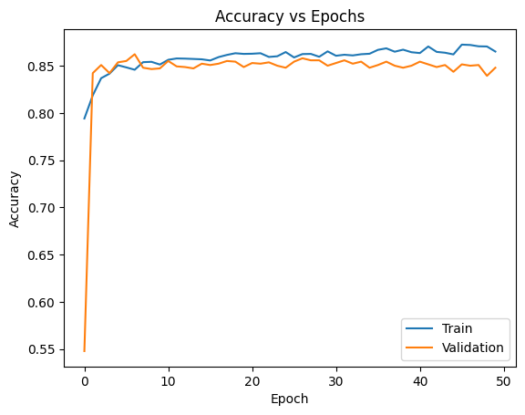

```python
#Plotting Training Accuracy vs Validation Accuracy
plt.plot(history_3.history['accuracy'])
plt.plot(history_3.history['val_accuracy'])
plt.title('Accuracy vs Epochs')
plt.ylabel('Accuracy')
plt.xlabel('Epoch')
plt.legend(['Train', 'Validation'], loc='lower right')
plt.show()
```

The accuracy graphs between the 2 datasets indicate consistency and the model is generalizing well.

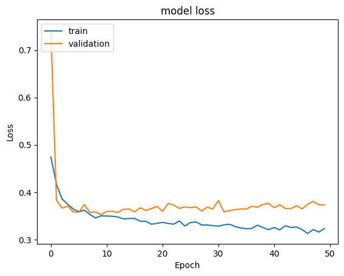

```python
#Plotting Train Loss vs Validation Loss
plt.plot(history_3.history['loss'])
plt.plot(history_3.history['val_loss'])
plt.title('model loss')
plt.ylabel('Loss')
plt.xlabel('Epoch')
plt.legend(['train', 'validation'], loc='upper left')
plt.show()
```

Slight noise/fluctuation is observed in the validation loss graph but the model seems to be generalizing well and not overfitting.

```python
score3 = model_3.evaluate(X_test, y_test)
```

```
Best Threshold=0.219966, G-Mean=0.766
```

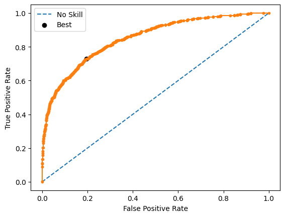

```python
#Draw the ROC Curve
# predict probabilities
ypred_3 = model_3.predict(X_test)
# keep probabilities for the positive outcome only
ypred_3 = ypred_3[:, 0]
ypred_3 = draw_roc_curve(ypred_3)
```

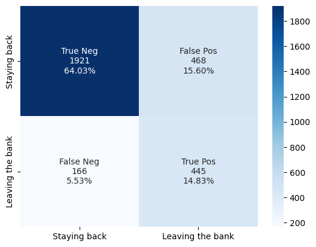

```python
#Calculating the confusion matrix
from sklearn.metrics import confusion_matrix
cm1=confusion_matrix(y_test, ypred_3)

labels = ['True Neg','False Pos','False Neg','True Pos']
categories = [ 'Staying back','Leaving the bank']
make_confusion_matrix(cm1,
                      group_names=labels,
                      categories=categories,
                      cmap='Blues')
```

The False Negatives of 166 in this model (Model3) are more than what we got from Model2 (121). So adding layers and BatchNormalization did not help.

```python
#Accuracy as per the classification report
cr=classification_report(y_test,ypred_3)
print(cr)
```

```
              precision    recall  f1-score   support

           0       0.92      0.80      0.86      2389
           1       0.49      0.73      0.58       611

    accuracy                           0.79      3000
   macro avg       0.70      0.77      0.72      3000
weighted avg       0.83      0.79      0.80      3000
```

```python
recall3 =0.73
```

Model 3 gives a recall score of 0.73.

Adding 2 layers along with the Dropout and BatchNormalization techniques in fact brought the recall value down from 0.80 (in Model2) to 0.73.

Now, let's try to use some of the Hyperparameter Optimization techniques we have learnt, GridSearchCV and Keras Tuner to increase the recall value further.